# 432 Class 09

Thomas E. Love, Ph.D.

2024-02-13

## Today’s Agenda, Part I

- A New NHANES Example
- [Logistic Regression Analyses in Project A](https://thomaselove.github.io/432-2024/projA.html#new-section-9.-logistic-regression-analyses)
  - Establishing a Research Question
  - Identifying / Tidying Outcome and Candidate Predictors
  - Dealing with Missing Data
  - Building a “Main Effects” Model Y and Plotting Effects
  - Considering Non-Linear Terms
  - Fitting an “Augmented” Model Z and Plotting Effects

## Today’s Agenda, II

- Summarizing/Presenting a Final Model
  - In-Sample and Validated Model Summaries
  - Selecting Model Y or Model Z
  - Describing a Meaningful Effect (see Notes, Chapter 22)
  - ROC curve for the Final Model
  - Nomogram for the Final Model

## Today’s R Setup

```r
knitr::opts_chunk$set(comment = NA)

library(nhanesA)
library(broom)
library(caret)
library(janitor)
library(gt)
library(mosaic)
library(naniar)
library(pROC)
library(rms)
library(simputation)
library(tidyverse)

theme_set(theme_bw())
```

# The Data

## NHANES 2011-12 Data

We’ll use data from the 2011-2012 administration of NHANES here, specifically including variables from these data bases.

- **DEMO_G** for Demographic Variables
- **CDQ_G** for Cardiovascular Health Questionnaire
- **HSQ_G** for Current Health Status Questionnaire
- **BPX_G** for Blood Pressure Examination Results
- **BMX_G** for Body Measures Examination Results
- **MCQ_G** for Medical Conditions Questionnaire

## Pulling the Data

```r
demo_g <- nhanes("DEMO_G", translated = FALSE) |> tibble(); dim(demo_g)
```

```
[1] 9756   48
```

```r
cdq_g <- nhanes("CDQ_G", translated = FALSE) |> tibble(); dim(cdq_g)
```

```
[1] 3603   17
```

```r
hsq_g <- nhanes("HSQ_G", translated = FALSE) |> tibble(); dim(hsq_g)
```

```
[1] 8956   14
```

```r
bpx_g <- nhanes("BPX_G", translated = FALSE) |> tibble(); dim(bpx_g)
```

```
[1] 9338   27
```

```r
bmx_g <- nhanes("BMX_G", translated = FALSE) |> tibble(); dim(bmx_g)
```

```
[1] 9338   26
```

```r
mcq_g <- nhanes("MCQ_G", translated = FALSE) |> tibble(); dim(mcq_g)
```

```
[1] 9364   92
```

## Merging the Tibbles

```r
df_mlist <- list(demo_g, cdq_g, hsq_g, bpx_g, bmx_g, mcq_g)

nh_merge <- df_mlist |>
  reduce(left_join, by = "SEQN") # reduce is from purrr

dim(nh_merge)
```

```
[1] 9756  219
```

- We had 224 variables in our original six tibbles, but that counts the SEQN variable six times, and we only have it once in our `nh_merge` tibble.

Which of these 219 variables are we actually going to use?

## Seven Variables Used Today

| NHANES | Description | Source |
| --- | --- | --- |
| SEQN | Identifying code | All 6 files |
| CDQ010 | Short of breath on stairs/inclines? | CDQ_G |
| RIDAGEYR | Age in years at screening | DEMO_G |
| HSD010 | General health (E/VG/G/F/P) | HSQ_G |
| BPXDI1 | Diastolic BP (first reading, in mm Hg) | BPX_G |
| BMXBMI | Body Mass Index (kg/$m^2$) | BMX_G |
| MCQ010 | Ever told you have asthma? | MCQ_G |

## Selecting Today’s Variables

We’re filtering to people with a 1 or 2 on CDQ010, and with RIDAGEYR < 80, and we’ll also rename some of the variables.

```r
nh_today <- nh_merge |>
  select(SEQN, CDQ010, age = RIDAGEYR, sroh = HSD010,
         dbp = BPXDI1, bmi = BMXBMI,
         asthma = MCQ010) |>
  filter(CDQ010 < 3) |>
  filter(age < 80)

dim(nh_today)
```

```
[1] 3234    7
```

## Data Checking and Cleaning (1)

1. SEQN should be unique for each row in the data.

```r
identical(nrow(nh_today), n_distinct(nh_today$SEQN))
```

```
[1] TRUE
```

## Data Checking and Cleaning (2)

2. CDQ010 was 1 for Yes, 2 for No. We want 1 for Yes, 0 for No.
- We’ll also name this new variable `sbreath` (for shortness of breath) and place it immediately after the subject ID `SEQN`.

```r
nh_today <- nh_today |> mutate(sbreath = 2 - CDQ010)

nh_today |> count(CDQ010, sbreath) # sanity check
```

```
# A tibble: 2 × 3
  CDQ010 sbreath     n
   <dbl>   <dbl> <int>
1      1       1  1015
2      2       0  2219
```

```r
nh_today <- nh_today |> select(-CDQ010) |>
  relocate(sbreath, .after = "SEQN")
```

## Data Checking and Cleaning (3-5)

3. Age should be between 40 and 79 years
4. Body mass index should be between 12.4 and 82.1 kg/$m^2$
5. Diastolic BP should be between 30 and 120 mm Hg (treat values below 30 as NA)

```r
df_stats(~ age + bmi + dbp, data = nh_today) |>
  rename(var = response) |> gt() |> tab_options(table.font.size = 24)
```

| var | min | Q1 | median | Q3 | max | mean | sd | n | missing |
| --- | --- | --- | --- | --- | --- | --- | --- | --- | --- |
| age | 40.0 | 48.0 | 57.0 | 65.0 | 79.0 | 57.34818 | 10.699621 | 3234 | 0 |
| bmi | 13.6 | 24.7 | 28.3 | 32.9 | 82.1 | 29.52410 | 6.874603 | 3062 | 172 |
| dbp | 0.0 | 66.0 | 74.0 | 80.0 | 120.0 | 73.11493 | 12.438088 | 2854 | 380 |

## Replace `dbp` values below 30 with NA

```r
nh_today |> count(dbp < 30)
```

```
# A tibble: 3 × 2
  `dbp < 30`     n
  <lgl>      <int>
1 FALSE       2842
2 TRUE          12
3 NA           380
```

```r
nh_today <- replace_with_na_at(nh_today, "dbp", ~ .x < 30)

favstats(~ dbp, data = nh_today) |> gt() |> tab_options(table.font.size = 24)
```

| min | Q1 | median | Q3 | max | mean | sd | n | missing |
| --- | --- | --- | --- | --- | --- | --- | --- | --- |
| 30 | 66 | 74 | 80 | 120 | 73.40957 | 11.59503 | 2842 | 392 |

## Data Checking and Cleaning (6)

6. `asthma` should be recoded into a two-level factor (it is currently 1 = Yes, 2 = No, and 9 = Don’t Know, which we’ll treat as missing)

```r
nh_today <- nh_today |>
  mutate(asthma = fct_recode( factor(asthma),
                              "Yes" = "1", "No" = "2", NULL = "9"),
    asthma = fct_relevel(asthma, "No"))

nh_today |> tabyl(asthma) |> adorn_pct_formatting()
```

```
 asthma    n percent valid_percent
     No 2779   85.9%         86.0%
    Yes  452   14.0%         14.0%
   <NA>    3    0.1%             -
```

## Data Checking and Cleaning (7)

7. Self-reported overall health should be a five-level factor

```r
nh_today <- nh_today |>
  mutate(sroh = fct_recode(factor(sroh), "E" = "1", "VG" = "2",
                           "G" = "3", "F" = "4", "P" = "5"))
nh_today |> tabyl(sroh) |> adorn_pct_formatting() |>
  gt() |> tab_options(table.font.size = 20)
```

| sroh | n | percent | valid_percent |
| --- | --- | --- | --- |
| E | 238 | 7.4% | 8.5% |
| VG | 684 | 21.2% | 24.5% |
| G | 1119 | 34.6% | 40.1% |
| F | 612 | 18.9% | 21.9% |
| P | 136 | 4.2% | 4.9% |
| NA | 445 | 13.8% | - |

## So, what is missing?

```r
miss_var_summary(nh_today)
```

```
# A tibble: 7 × 3
  variable n_miss pct_miss
  <chr>     <int>    <dbl>
1 sroh        445  13.8
2 dbp         392  12.1
3 bmi         172   5.32
4 asthma        3   0.0928
5 SEQN          0   0
6 sbreath       0   0
7 age           0   0
```

```r
miss_case_table(nh_today)
```

```
# A tibble: 4 × 3
  n_miss_in_case n_cases pct_cases
           <int>   <int>     <dbl>
1              0    2555     79.0
2              1     475     14.7
3              2      75      2.32
4              3     129      3.99
```

## Where are we?

We have 3234 rows and 7 columns in the `nh_today` data now.

- 2555, or 79%, of rows are complete on these 7 variables.
- Inclusions/Exclusions: Valid (1 or 0) response to `sbreath`, `age` between 40 and 79 years, inclusive.

## Using `Hmisc::describe()`

```r
nh_today |> describe()
```

```
nh_today

 7  Variables      3234  Observations
--------------------------------------------------------------------------------
SEQN
       n  missing distinct     Info     Mean      Gmd      .05      .10
    3234        0     3234        1    67069     3246    62681    63175
     .25      .50      .75      .90      .95
   64606    67139    69479    70953    71410

lowest : 62164 62172 62177 62179 62182, highest: 71901 71902 71908 71912 71915
--------------------------------------------------------------------------------
sbreath
       n  missing distinct     Info      Sum     Mean      Gmd
    3234        0        2    0.646     1015   0.3139   0.4308

--------------------------------------------------------------------------------
age
       n  missing distinct     Info     Mean      Gmd      .05      .10
    3234        0       40    0.999    57.35    12.31       41       43
     .25      .50      .75      .90      .95
      48       57       65       73       76

lowest : 40 41 42 43 44, highest: 75 76 77 78 79
--------------------------------------------------------------------------------
sroh
       n  missing distinct
    2789      445        5

Value          E    VG     G     F     P
Frequency    238   684  1119   612   136
Proportion 0.085 0.245 0.401 0.219 0.049
--------------------------------------------------------------------------------
dbp
       n  missing distinct     Info     Mean      Gmd      .05      .10
    2842      392       45    0.997    73.41    12.88       54       58
     .25      .50      .75      .90      .95
      66       74       80       88       92

lowest :  30  32  34  36  38, highest: 110 112 114 118 120
--------------------------------------------------------------------------------
bmi
       n  missing distinct     Info     Mean      Gmd      .05      .10
    3062      172      345        1    29.52    7.303    20.90    22.30
     .25      .50      .75      .90      .95
   24.70    28.30    32.90    38.39    41.90

lowest : 13.6 14.3 15.4 16.2 16.5, highest: 65.1 66.2 67.3 68.7 82.1
--------------------------------------------------------------------------------
asthma
       n  missing distinct
    3231        3        2

Value        No  Yes
Frequency  2779  452
Proportion 0.86 0.14
--------------------------------------------------------------------------------
```

## Revised Codebook

| Name | Description |
| --- | --- |
| SEQN | Identifying code |
| sbreath | Short of breath on stairs/inclines? (1 = Yes, 0 = No) |
| age | Age in years at screening |
| sroh | Self-reported health (E/VG/G/F/P) |
| dbp | Diastolic BP (1st reading, in mm Hg) |
| bmi | Body Mass Index (kg/$m^2$) |
| asthma | Ever told you have asthma? (Yes or No) |

# Project A Tasks

## Establishing our Research Question

How effectively can we predict whether or not an adult subject has experienced “shortness of breath when hurrying on the level or walking up a slight hill” on the basis of their age, self-reported overall health, diastolic blood pressure, body mass index and whether or not they have been told they have asthma?

- Our data come from NHANES 2011-12, and describe a total of 3234 (unweighted) adult (ages 40-79) subjects.
- We will not use survey weights in this work.

## Specifying / Tidying the Outcome

Our outcome (`sbreath`) is the subject’s response to:

> **Have you had shortness of breath either when hurrying on the level or walking up a slight hill?**

This was asked of adults ages 40 years and up as `CDQ010` on the `CDQ_G` questionnaire in NHANES 2011-12, and we’re studying those who responded 1 for Yes, or 0 for No.

```r
nh_today |> tabyl(sbreath) |> adorn_totals() |>
  adorn_pct_formatting()
```

```
 sbreath    n percent
       0 2219   68.6%
       1 1015   31.4%
   Total 3234  100.0%
```

## Our Five Candidate Predictors

The five predictors we will consider for this outcome are `age`, `sroh`, `dbp`, `bmi` and `asthma`. Our sample has 3234 subjects.

| Name | Description | Missing? |
| --- | --- | --- |
| age | Age in years at screening | None |
| sroh | Self-reported health (E/VG/G/F/P) | 445 |
| dbp | Diastolic BP (1st reading, in mm Hg) | 392 |
| bmi | Body Mass Index (kg/$m^2$) | 172 |
| asthma | Ever been told you have asthma? | 3 |

## Dealing with Missing Data

We have excluded all cases with missing `sbreath` so our outcome is complete.

We will assume missing at random (MAR) for the missing values in our candidate predictors, and then use single imputation to complete the rest of our work, including…

- building a Spearman $\rho^2$ plot, and
- fitting and evaluating our models Y (only linear terms) and Z (include non-linear terms)

## Using Multiple Imputation instead?

If you wanted to use multiple imputation in the project, that’s OK, but I would do that at the end, by refitting the “winning” model and summarizing those results (after imputation) only as part of your **Final Model** materials.

- In this case, given that I have complete data on 79% of my rows (so missing data in 21%) I would probably perform either 25 or 30 imputations.
- I’ll demonstrate multiple imputation in a logistic regression setting (using `aregImpute()`) next time (Class 10.)

## Single Imputation via `simputation`

- Variables I must impute: `sroh`, `dbp`, `bmi`, `asthma`
- Variables with complete data: `SEQN` (useless identifier), `sbreath` (my outcome), and `age`.

```r
set.seed(43212345)
nh_today_i <- nh_today |> data.frame() |>
  impute_rhd(asthma ~ age) |>
  impute_rlm(dbp ~ age + asthma) |>
  impute_rlm(bmi ~ dbp + age + asthma) |>
  impute_cart(sroh ~ age + bmi) |>
  as_tibble()

n_miss(nh_today_i) # should now show no missing data
```

```
[1] 0
```

# Model Y: “Main Effects”

## Building our “Main Effects” Model

We assume MAR and analyze the (singly) imputed data `nh_today_i`

```r
d <- datadist(nh_today_i)
options(datadist = "d")

modY_si <- lrm(sbreath ~ age + sroh + dbp + bmi + asthma,
            data = nh_today_i, x = TRUE, y = TRUE)
```

## `modY_si` results (from `lrm` fit)

```r
modY_si
```

```
Logistic Regression Model

lrm(formula = sbreath ~ age + sroh + dbp + bmi + asthma, data = nh_today_i,
    x = TRUE, y = TRUE)

                       Model Likelihood       Discrimination    Rank Discrim.
                             Ratio Test              Indexes          Indexes
Obs          3234    LR chi2     426.39       R2       0.174    C       0.718
 0           2219    d.f.             8      R2(8,3234)0.121    Dxy     0.436
 1           1015    Pr(> chi2) <0.0001    R2(8,2089.3)0.181    gamma   0.436
max |deriv| 2e-10                             Brier    0.187    tau-a   0.188

           Coef    S.E.   Wald Z Pr(>|Z|)
Intercept  -4.1132 0.4878 -8.43  <0.0001
age         0.0149 0.0039  3.79  0.0002
sroh=VG     0.4849 0.2337  2.07  0.0380
sroh=G      1.1641 0.2179  5.34  <0.0001
sroh=F      1.8890 0.2269  8.33  <0.0001
sroh=P      1.9771 0.2780  7.11  <0.0001
dbp        -0.0062 0.0038 -1.63  0.1033
bmi         0.0544 0.0062  8.79  <0.0001
asthma=Yes  0.7981 0.1111  7.18  <0.0001
```

## Two Summaries from `modY_si`

Here, the Nagelkerke $R^2$ is 0.174 and the C statistic is 0.718.

- The Nagelkerke $R^2$ measures goodness of fit of our logistic regression model. It’s best interpreted as an improvement from a null (intercept only) model to our fitted one.
  - It is an adjusted Cox-Snell $R^2$ that ranges from 0 to 1, with higher $R^2$ indicating better fit.
  - A Nagelkerke $R^2$ doesn’t describe “a percentage of explained variation” nor is it the square of a correlation.
- The C statistic is the area under the ROC curve.

## `glm` version of this same fit

```r
modY_si_g <- glm(sbreath ~ age + sroh + dbp + bmi + asthma,
            data = nh_today_i,
            family = binomial(link = logit))

modY_si_g
```

```
Call:  glm(formula = sbreath ~ age + sroh + dbp + bmi + asthma, family = binomial(link = logit),
    data = nh_today_i)

Coefficients:
(Intercept)          age       srohVG        srohG        srohF        srohP
  -4.113185     0.014921     0.484919     1.164107     1.888952     1.977082
        dbp          bmi    asthmaYes
  -0.006171     0.054416     0.798134

Degrees of Freedom: 3233 Total (i.e. Null);  3225 Residual
Null Deviance:      4024
Residual Deviance: 3598     AIC: 3616
```

## `modY_si_g` (Exponentiated) Coefficients

```r
tidy(modY_si_g, exponentiate = TRUE,
     conf.int = TRUE, conf.level = 0.90) |>
  select(term, estimate, std.error,
         low90 = conf.low, high90 = conf.high,
         p = p.value) |>
  gt() |>
  fmt_number(decimals = 3) |>
  tab_options(table.font.size = 24)
```

## `modY_si_g` (Exponentiated) Coefficients

| term | estimate | std.error | low90 | high90 | p |
| --- | --- | --- | --- | --- | --- |
| (Intercept) | 0.016 | 0.488 | 0.007 | 0.036 | 0.000 |
| age | 1.015 | 0.004 | 1.008 | 1.022 | 0.000 |
| srohVG | 1.624 | 0.234 | 1.117 | 2.415 | 0.038 |
| srohG | 3.203 | 0.218 | 2.267 | 4.652 | 0.000 |
| srohF | 6.612 | 0.227 | 4.607 | 9.737 | 0.000 |
| srohP | 7.222 | 0.278 | 4.609 | 11.519 | 0.000 |
| dbp | 0.994 | 0.004 | 0.988 | 1.000 | 0.103 |
| bmi | 1.056 | 0.006 | 1.045 | 1.067 | 0.000 |
| asthmaYes | 2.221 | 0.111 | 1.850 | 2.667 | 0.000 |

## `glance()` for `modY_si_g`

```r
glance(modY_si_g) |>
  gt() |> tab_options(table.font.size = 24)
```

| null.deviance | df.null | logLik | AIC | BIC | deviance | df.residual | nobs |
| --- | --- | --- | --- | --- | --- | --- | --- |
| 4024.058 | 3233 | -1798.832 | 3615.664 | 3670.398 | 3597.664 | 3225 | 3234 |

## `modY_si` Effects (Odds Ratio Scale)

```r
plot(summary(modY_si))
```

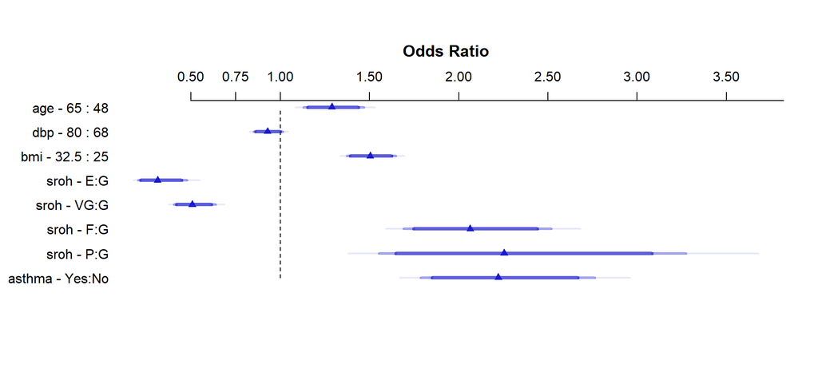

## Details of Effects Plot (`modY_si`)

```r
summary(modY_si)
```

```
             Effects              Response : sbreath

 Factor          Low High Diff. Effect    S.E.     Lower 0.95 Upper 0.95
 age             48  65.0 17.0   0.253660 0.066962  0.12242    0.384900
  Odds Ratio     48  65.0 17.0   1.288700       NA  1.13020    1.469500
 dbp             68  80.0 12.0  -0.074048 0.045455 -0.16314    0.015043
  Odds Ratio     68  80.0 12.0   0.928630       NA  0.84947    1.015200
 bmi             25  32.5  7.5   0.408120 0.046411  0.31716    0.499080
  Odds Ratio     25  32.5  7.5   1.504000       NA  1.37320    1.647200
 sroh - E:G       3   1.0   NA  -1.164100 0.217900 -1.59120   -0.737040
  Odds Ratio      3   1.0   NA   0.312200       NA  0.20369    0.478530
 sroh - VG:G      3   2.0   NA  -0.679190 0.116900 -0.90831   -0.450060
  Odds Ratio      3   2.0   NA   0.507030       NA  0.40320    0.637590
 sroh - F:G       3   4.0   NA   0.724850 0.101520  0.52588    0.923810
  Odds Ratio      3   4.0   NA   2.064400       NA  1.69190    2.518900
 sroh - P:G       3   5.0   NA   0.812980 0.190200  0.44019    1.185800
  Odds Ratio      3   5.0   NA   2.254600       NA  1.55300    3.273200
 asthma - Yes:No  1   2.0   NA   0.798130 0.111120  0.58035    1.015900
  Odds Ratio      1   2.0   NA   2.221400       NA  1.78670    2.761900
```

## Prediction Plot for `modY_si`

```r
ggplot(Predict(modY_si, fun = plogis))
```

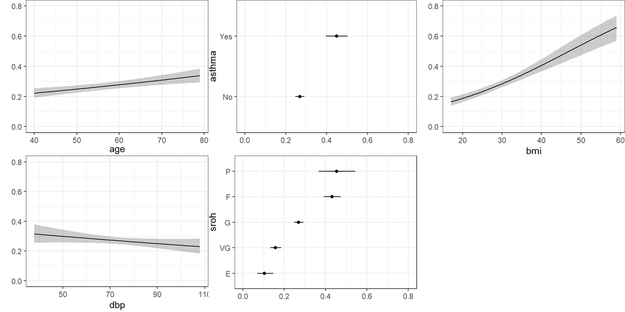

## Confusion Matrix for `modY_si`

How well does `modY_si` classify subjects using a decision rule at 0.5?

```r
modY_aug <- augment(modY_si_g, type.predict = "response")

modY_aug <- modY_aug |>
  mutate(pred = ifelse(.fitted >= 0.5, "Predict SB", "Predict No SB"))

modY_aug |> tabyl(pred, sbreath) |>
  adorn_totals(where = c("row", "col")) |> adorn_title()
```

```
               sbreath
          pred       0    1 Total
 Predict No SB    2040  726  2766
    Predict SB     179  289   468
         Total    2219 1015  3234
```

- What fraction of our predictions are correct with this decision rule?

## `modY_si` Classification, 1

```
               sbreath
          pred       0    1 Total
 Predict No SB    2040  726  2766
    Predict SB     179  289   468
         Total    2219 1015  3234
```

- **Accuracy** is (2040 + 289) / 3234 = 0.720
  - 72.0% of this model’s predictions were accurate.

## `modY_si` Classification, 2

```
               sbreath
          pred       0    1 Total
 Predict No SB    2040  726  2766
    Predict SB     179  289   468
         Total    2219 1015  3234
```

- **Sensitivity** is 289 / 1015 = 0.285
  - 28.5% of those who actually were short of breath are predicted to be short of breath.
- **Specificity** is 2040 / 2219 = 0.919
  - 91.9% of those who actually weren’t short of breath were predicted not to be short of breath.

## `modY_si` Classification, 3

```
               sbreath
          pred       0    1 Total
 Predict No SB    2040  726  2766
    Predict SB     179  289   468
         Total    2219 1015  3234
```

- **Positive Predictive Value (PPV)** is 289 / 468 = 0.618
  - 61.8% of those predicted to be short of breath actually were short of breath.
- **Negative Predictive Value (NPV)** is 2040 / 2766 = 0.738
  - 73.8% of those predicted to not be short of breath actually were not short of breath.

## A confusion matrix from `caret`

```r
cmY <- confusionMatrix(
  data = factor(modY_aug$.fitted >= 0.5),
  reference = factor(modY_aug$sbreath == 1),
  positive = "TRUE")

cmY
```

```
Confusion Matrix and Statistics

          Reference
Prediction FALSE TRUE
     FALSE  2040  726
     TRUE    179  289

               Accuracy : 0.7202
                 95% CI : (0.7043, 0.7356)
    No Information Rate : 0.6861
    P-Value [Acc > NIR] : 1.393e-05

                  Kappa : 0.239

 Mcnemar's Test P-Value : < 2.2e-16

            Sensitivity : 0.28473
            Specificity : 0.91933
         Pos Pred Value : 0.61752
         Neg Pred Value : 0.73753
             Prevalence : 0.31385
         Detection Rate : 0.08936
   Detection Prevalence : 0.14471
      Balanced Accuracy : 0.60203

       'Positive' Class : TRUE
```

## Calibration Plot for Model Y

```r
plot(calibrate(modY_si))
```

```
n=3234   Mean absolute error=0.009   Mean squared error=0.00021
0.9 Quantile of absolute error=0.022
```

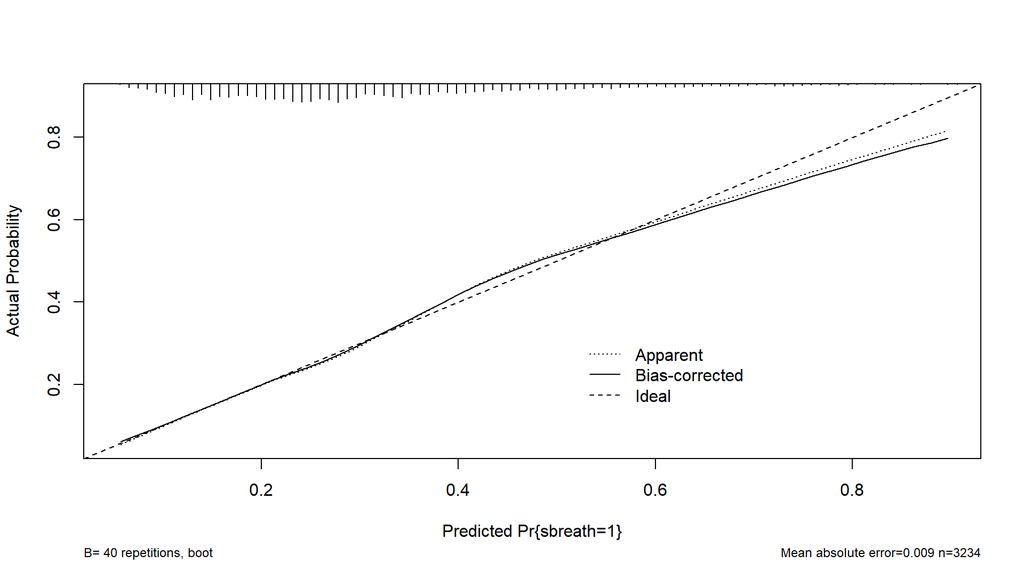

# Model Z: The “Augmented” model

## Considering Non-Linear Terms

- Use 3-6 additional degrees of freedom to account for non-linearity, and add 1-3 non-linear terms.
- We’ll start with the Spearman $\rho^2$ plot…

## Spearman $\rho^2$ plot

```r
plot(spearman2(sbreath ~ age + sroh + dbp + bmi + asthma,
            data = nh_today_i))
```

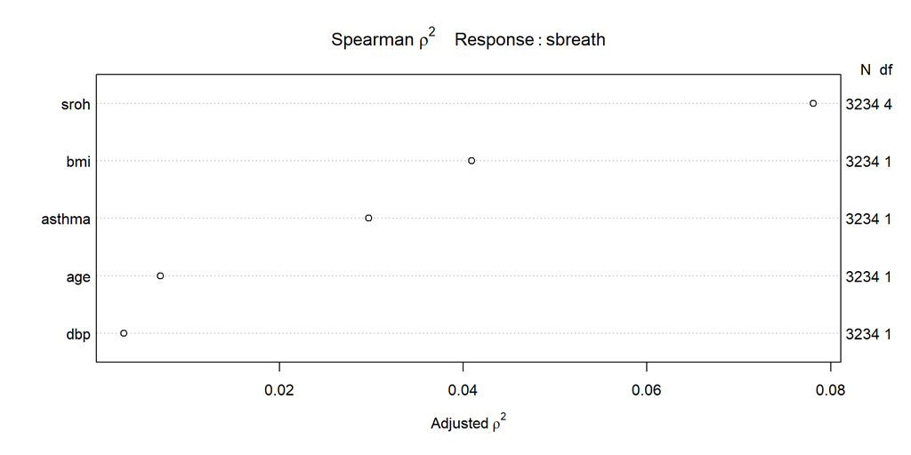

## Fitting an “Augmented” Model

We’ll add two terms, and stop there.

- the interaction of `sroh` and `bmi`, which will add 4 df, and
- a restricted cubic spline with three knots in `bmi`, which will add one more df.

In all, this should be an additional 5 df.

```r
## note: datadist has already been set up

modZ_si <- lrm(sbreath ~ age + sroh + rcs(bmi,3) +
                 sroh %ia% bmi + dbp + asthma,
            data = nh_today_i, x = TRUE, y = TRUE)
```

## Checking our df

As the ANOVA table below shows, we have indeed added 5 degrees of freedom with our non-linear and interaction terms.

```r
anova(modZ_si)
```

```
                Wald Statistics          Response: sbreath

 Factor                                    Chi-Square d.f. P
 age                                        14.08      1   0.0002
 sroh  (Factor+Higher Order Factors)       165.26      8   <.0001
  All Interactions                           1.79      4   0.7745
 bmi  (Factor+Higher Order Factors)         79.65      6   <.0001
  All Interactions                           1.79      4   0.7745
  Nonlinear                                  0.21      1   0.6461
 sroh * bmi  (Factor+Higher Order Factors)   1.79      4   0.7745
 dbp                                         2.63      1   0.1047
 asthma                                     52.03      1   <.0001
 TOTAL NONLINEAR + INTERACTION               1.89      5   0.8642
 TOTAL                                     352.90     13   <.0001
```

## `modZ_si` results (from `lrm` fit)

```r
modZ_si
```

```
Logistic Regression Model

lrm(formula = sbreath ~ age + sroh + rcs(bmi, 3) + sroh %ia%
    bmi + dbp + asthma, data = nh_today_i, x = TRUE, y = TRUE)

                       Model Likelihood        Discrimination    Rank Discrim.
                             Ratio Test               Indexes          Indexes
Obs          3234    LR chi2     428.25        R2       0.174    C       0.719
 0           2219    d.f.            13      R2(13,3234)0.120    Dxy     0.438
 1           1015    Pr(> chi2) <0.0001    R2(13,2089.3)0.180    gamma   0.438
max |deriv| 4e-09                              Brier    0.187    tau-a   0.189

              Coef    S.E.   Wald Z Pr(>|Z|)
Intercept     -4.2765 1.1558 -3.70  0.0002
age            0.0148 0.0039  3.75  0.0002
sroh=VG        0.4052 1.1722  0.35  0.7295
sroh=G         1.5974 1.0686  1.49  0.1350
sroh=F         2.1630 1.0985  1.97  0.0489
sroh=P         2.9370 1.2318  2.38  0.0171
bmi            0.0596 0.0387  1.54  0.1235
bmi'           0.0095 0.0207  0.46  0.6461
sroh=VG * bmi  0.0023 0.0402  0.06  0.9539
sroh=G * bmi  -0.0151 0.0368 -0.41  0.6811
sroh=F * bmi  -0.0100 0.0376 -0.27  0.7907
sroh=P * bmi  -0.0323 0.0414 -0.78  0.4352
dbp           -0.0061 0.0038 -1.62  0.1047
asthma=Yes     0.8017 0.1111  7.21  <0.0001
```

## glm version of Model Z

```r
modZ_si_g <- glm(sbreath ~ age + sroh + rcs(bmi, 3) +
                   sroh %ia% bmi + dbp + asthma,
                 data =nh_today_i,
                 family =binomial(link =logit))

modZ_si_g
```

```
Call:  glm(formula = sbreath ~ age + sroh + rcs(bmi, 3) + sroh %ia%
    bmi + dbp + asthma, family = binomial(link = logit), data = nh_today_i)

Coefficients:
               (Intercept)                         age
                 -4.276453                    0.014819
                    srohVG                       srohG
                  0.405248                    1.597374
                     srohF                       srohP
                  2.163030                    2.937031
            rcs(bmi, 3)bmi             rcs(bmi, 3)bmi'
                  0.059582                    0.009525
sroh %ia% bmisroh=VG * bmi   sroh %ia% bmisroh=G * bmi
                  0.002326                   -0.015125
 sroh %ia% bmisroh=F * bmi   sroh %ia% bmisroh=P * bmi
                 -0.009987                   -0.032268
                       dbp                   asthmaYes
                 -0.006146                    0.801692

Degrees of Freedom: 3233 Total (i.e. Null);  3220 Residual
Null Deviance:      4024
Residual Deviance: 3596     AIC: 3624
```

## Tidied Model Z (Exponentiated)

Here are the tidied coefficients (as odds ratios, after exponentiation) from model `modZ_si_g`.

```r
tidy(modZ_si_g, exponentiate = TRUE,
     conf.int = TRUE, conf.level = 0.90) |>
  select(term, estimate, std.error,
         low90 = conf.low, high90 = conf.high) |>
  gt() |>
  fmt_number(decimals = 3) |>
  tab_options(table.font.size = 14)
```

## Tidied Model Z (Exponentiated)

| term | estimate | std.error | low90 | high90 |
| --- | --- | --- | --- | --- |
| (Intercept) | 0.014 | 1.156 | 0.002 | 0.092 |
| age | 1.015 | 0.004 | 1.008 | 1.022 |
| srohVG | 1.500 | 1.172 | 0.215 | 10.758 |
| srohG | 4.940 | 1.068 | 0.836 | 30.246 |
| srohF | 8.697 | 1.098 | 1.402 | 55.705 |
| srohP | 18.860 | 1.232 | 2.436 | 147.704 |
| rcs(bmi, 3)bmi | 1.061 | 0.039 | 0.995 | 1.132 |
| rcs(bmi, 3)bmi' | 1.010 | 0.021 | 0.976 | 1.045 |
| sroh %ia% bmisroh=VG * bmi | 1.002 | 0.040 | 0.937 | 1.072 |
| sroh %ia% bmisroh=G * bmi | 0.985 | 0.037 | 0.926 | 1.049 |
| sroh %ia% bmisroh=F * bmi | 0.990 | 0.038 | 0.930 | 1.055 |
| sroh %ia% bmisroh=P * bmi | 0.968 | 0.041 | 0.904 | 1.038 |
| dbp | 0.994 | 0.004 | 0.988 | 1.000 |
| asthmaYes | 2.229 | 0.111 | 1.857 | 2.677 |

## `glance()` for `modZ_si_g`

```r
glance(modZ_si_g) |>
  gt() |> tab_options(table.font.size = 24)
```

| null.deviance | df.null | logLik | AIC | BIC | deviance | df.residual | nobs |
| --- | --- | --- | --- | --- | --- | --- | --- |
| 4024.058 | 3233 | -1797.904 | 3623.808 | 3708.949 | 3595.808 | 3220 | 3234 |

## Model Z Effects (Odds Ratios)

```r
plot(summary(modZ_si))
```

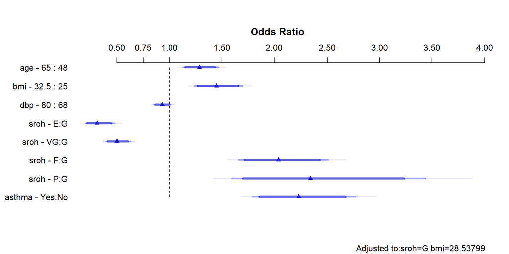

## Prediction Plot for Model Z

```r
ggplot(Predict(modZ_si, fun = plogis))
```

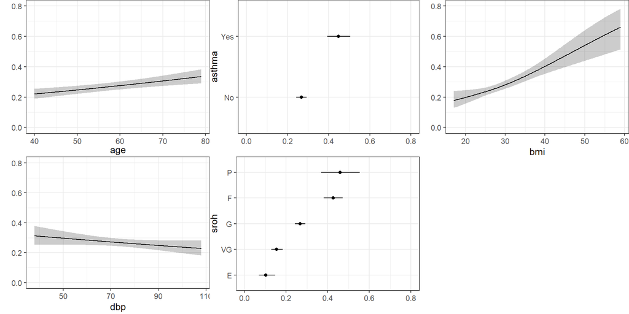

## Confusion Matrix for Model Z

How well does our Model Z classify subjects using a decision rule at 0.5?

```r
modZ_aug <- augment(modZ_si_g, type.predict = "response")

modZ_aug <- modZ_aug |>
  mutate(pred = ifelse(.fitted >= 0.5,
                       "Predict SB", "Predict No SB"))

modZ_aug |> tabyl(pred, sbreath) |>
  adorn_totals(where = c("row", "col")) |> adorn_title()
```

```
               sbreath
          pred       0    1 Total
 Predict No SB    2040  725  2765
    Predict SB     179  290   469
         Total    2219 1015  3234
```

## Classification Accuracy

- **Sensitivity** is only slightly changed, to 290 / 1015 = 0.286
  - 28.6% of those who actually were short of breath are predicted to be short of breath.
- **Specificity** is still 2040 / 2219 = 0.919
  - 91.9% of those who actually weren’t short of breath were predicted not to be short of breath.
- **Positive Predictive Value (PPV)** is 290 / 469 = 0.618
  - Again, 61.8% of those predicted to be short of breath actually were short of breath.

## Calibration Plot for Model Z

```r
plot(calibrate(modZ_si))
```

```
n=3234   Mean absolute error=0.01   Mean squared error=0.00024
0.9 Quantile of absolute error=0.022
```

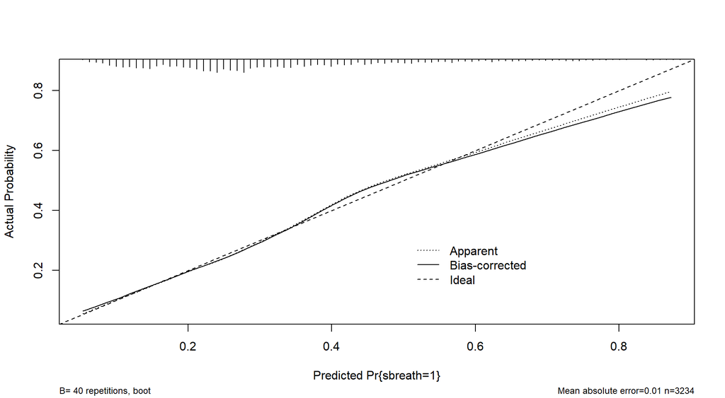

# Selecting and Presenting Your Final Model

## Model Y and Z Summaries

```r
temp1 <- bind_rows(glance(modY_si_g), glance(modZ_si_g)) |>
  mutate(model = c("Y", "Z")) |>
  select(model, AIC, BIC)

temp2 <- tibble(model = c("Y", "Z"),
  auc = c(modY_si$stats["C"], modZ_si$stats["C"]),
  r2_nag = c(modY_si$stats["R2"], modZ_si$stats["R2"]))

left_join(temp1, temp2, by = "model") |>
  gt() |> fmt_number(columns = AIC:BIC, decimals = 1) |>
  fmt_number(columns = auc:r2_nag, decimals = 4) |>
  tab_options(table.font.size = 24)
```

| model | AIC | BIC | auc | r2_nag |
| --- | --- | --- | --- | --- |
| Y | 3,615.7 | 3,670.4 | 0.7181 | 0.1735 |
| Z | 3,623.8 | 3,708.9 | 0.7188 | 0.1742 |

```r
anova(modZ_si)
```

```
                Wald Statistics          Response: sbreath

 Factor                                    Chi-Square d.f. P
 age                                        14.08      1   0.0002
 sroh  (Factor+Higher Order Factors)       165.26      8   <.0001
  All Interactions                           1.79      4   0.7745
 bmi  (Factor+Higher Order Factors)         79.65      6   <.0001
  All Interactions                           1.79      4   0.7745
  Nonlinear                                  0.21      1   0.6461
 sroh * bmi  (Factor+Higher Order Factors)   1.79      4   0.7745
 dbp                                         2.63      1   0.1047
 asthma                                     52.03      1   <.0001
 TOTAL NONLINEAR + INTERACTION               1.89      5   0.8642
 TOTAL                                     352.90     13   <.0001
```

## Validating Model Summaries

```r
set.seed(432123)
valY <- validate(modY_si, B = 40)
valZ <- validate(modZ_si, B = 40)

val_1 <- bind_rows(valY[1,], valZ[1,]) |>
  mutate(model = c("Y", "Z"),
         AUC_nominal = 0.5 + (index.orig/2),
         AUC_validated = 0.5 + (index.corrected/2)) |>
  select(model, AUC_nominal, AUC_validated)

val_2 <- bind_rows(valY[2,], valZ[2,]) |>
  mutate(model = c("Y", "Z"),
         R2_nominal = index.orig,
         R2_validated = index.corrected) |>
  select(model, R2_nominal, R2_validated)

val <- left_join(val_1, val_2, by = "model")

val |> gt() |> fmt_number(decimals = 4) |>
  tab_options(table.font.size = 24)
```

## Validating Model Summaries

| model | AUC_nominal | AUC_validated | R2_nominal | R2_validated |
| --- | --- | --- | --- | --- |
| Y | 0.7181 | 0.7163 | 0.1735 | 0.1693 |
| Z | 0.7188 | 0.7132 | 0.1742 | 0.1632 |

## Describing a Meaningful Effect

This is for you to do.

> [W]rite a detailed and correct description of the effect of at least one predictor on your outcome for your chosen logistic regression model, providing all necessary elements of such a description, and link this directly to what the (effects) plot is telling you.

See Chapter 22 of the Notes for more details, and this is also the major task in several Lab 4 questions.

- The effects plot for Model Y is repeated in the next slide, and you’ll want the actual summary as well as the plot so you can specify the numbers.
- We prefer you discuss a meaningful effect, should one exist. Pick an effect to describe that is interesting to you.

## Model Y Effects Plot

```r
plot(summary(modY_si))
```

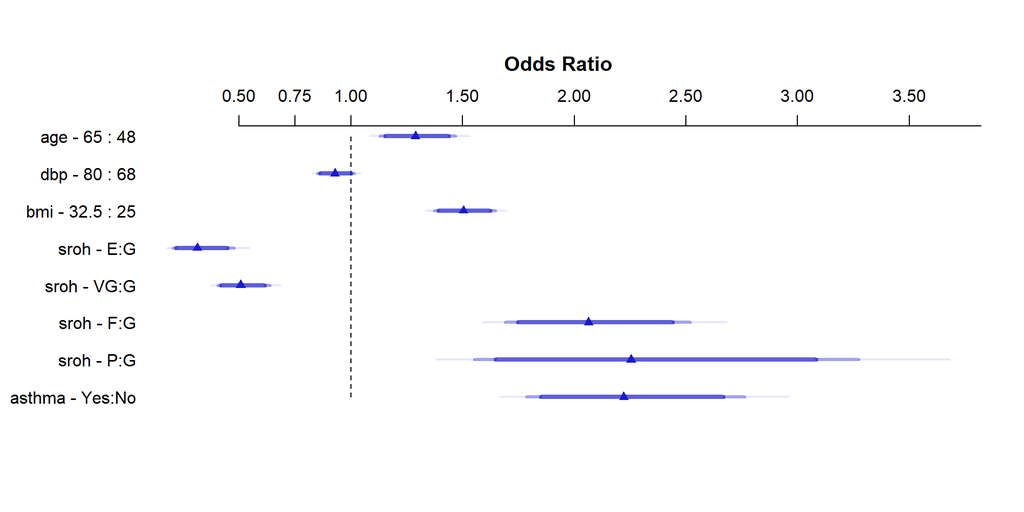

## Model Y Effects Summary

```r
summary(modY_si)
```

```
             Effects              Response : sbreath

 Factor          Low High Diff. Effect    S.E.     Lower 0.95 Upper 0.95
 age             48  65.0 17.0   0.253660 0.066962  0.12242    0.384900
  Odds Ratio     48  65.0 17.0   1.288700       NA  1.13020    1.469500
 dbp             68  80.0 12.0  -0.074048 0.045455 -0.16314    0.015043
  Odds Ratio     68  80.0 12.0   0.928630       NA  0.84947    1.015200
 bmi             25  32.5  7.5   0.408120 0.046411  0.31716    0.499080
  Odds Ratio     25  32.5  7.5   1.504000       NA  1.37320    1.647200
 sroh - E:G       3   1.0   NA  -1.164100 0.217900 -1.59120   -0.737040
  Odds Ratio      3   1.0   NA   0.312200       NA  0.20369    0.478530
 sroh - VG:G      3   2.0   NA  -0.679190 0.116900 -0.90831   -0.450060
  Odds Ratio      3   2.0   NA   0.507030       NA  0.40320    0.637590
 sroh - F:G       3   4.0   NA   0.724850 0.101520  0.52588    0.923810
  Odds Ratio      3   4.0   NA   2.064400       NA  1.69190    2.518900
 sroh - P:G       3   5.0   NA   0.812980 0.190200  0.44019    1.185800
  Odds Ratio      3   5.0   NA   2.254600       NA  1.55300    3.273200
 asthma - Yes:No  1   2.0   NA   0.798130 0.111120  0.58035    1.015900
  Odds Ratio      1   2.0   NA   2.221400       NA  1.78670    2.761900
```

## ROC Calculations for Model Y

```r
roc_modY <- roc(nh_today_i$sbreath ~
    predict(modY_si_g, type="response"), ci = TRUE)

roc_modY
```

```
Call:
roc.formula(formula = nh_today_i$sbreath ~ predict(modY_si_g,     type = "response"), ci = TRUE)

Data: predict(modY_si_g, type = "response") in 2219 controls (nh_today_i$sbreath 0) < 1015 cases (nh_today_i$sbreath 1).
Area under the curve: 0.7181
95% CI: 0.6992-0.7371 (DeLong)
```

```r
plot(roc_modY, main = "ROC Curve for Model Y",
     lwd = 2, col = "salmon")
legend('bottomright',
   legend = paste("AUC is: ",round_half_up(auc(roc_modY),3)))
```

## ROC plot for Model Y

[figure not shown]

## Nomogram for Model Y

- The final part of your summary of the final model should be a nomogram **with a demonstration of a predicted probability associated with two new subjects of interest** that differ in terms of some of the parameters in your model.
- Your predictions should describe two different subjects. You don’t have to call them Harry and Sally, but it is helpful to give them actual names.

```r
plot(nomogram(modY_si, fun = plogis,
              fun.at=c(seq(0.1, 0.9, by = 0.1)),
              funlabel = "Pr(shortB)"))
```

## Nomogram for Model Y

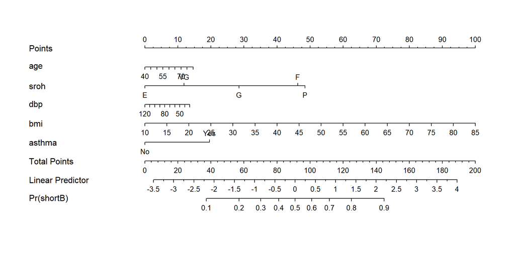

## Next Time

More on Logistic Regression

- See Chapter 20 for more on confusion matrices and ROC curves and some material on assessing assumptions through residual plots, all of which are in the context of logistic models fit with `glm()`.
- See Chapter 21 for more on using Spearman’s $\rho^2$ plot, Nagelkerke $R^2$, the C statistic, its relationship to Somers’ d, validation and plotting the results, along with some thoughts on identifying influential points, mostly in the context of logistic models fit with `lrm()`.
- See Chapter 22 for some thoughts on estimating and interpreting effect sizes in logistic and in linear models. Some really useful tips to be found here.

432 Class 09 | 2024-02-13 | https://thomaselove.github.io/432-2024/